# Capstone Project

Task 2

Wilfredo Dominguez

October 13, 2018

## Load a subset of the data

The objectives of this task are to 1) download the data, 2) summarize the dataset, 3) report interesting findings, and 4) receive feedback on plans to create a prediction algorithm.

### Objective 1. Download the dataset

The three datasets were download and sampled to create a manageable dataset.

```r
set.seed(1234)


###############################################
### Sample a subset of the data for Twitter
###############################################

file <- file(description = "en_US.twitter.txt", open = "r") #open file connection
i <- 1 #initialize counter
new.lines <- 0
sample.lines = list()
counter <- 0 #counter for number of lines
while(length(new.lines) != 0){   #do while there are at least 5 lines left in the file
          skip <- round((rnorm(n = 1, mean = 2500, sd = 300)),0) #Number of lines to skip
          counter <- counter+skip #counting total number of lines
          readLines(con = file, n = skip, warn = F) #skip these lines
          new.lines <- readLines(con = file, n = 1, warn = F) #read one line
          counter <- counter +1 #counting total number of lines
          sample.lines[[i]] <- new.lines #add line to list
          i <- i+1 #counter
}

close(file)


# counter #total number of lines in the file
# strsplit(x = as.character(sample.lines[1]), split = " ")

###############################################
####### Sample a subset of the data for Blogs
###############################################
file <- file(description = "en_US.blogs.txt", open = "r") #open file connection
new.lines <- 0

#sample.lines = list()
counter <- 0 #counter for number of lines
while(length(new.lines) != 0){   #do while there are at least 5 lines left in the file
          skip <- round((rnorm(n = 1, mean = 900, sd = 300)),0) #Number of lines to skip
          counter <- counter+skip #counting total number of lines
          readLines(con = file, n = skip, warn = F) #skip these lines
          new.lines <- readLines(con = file, n = 1, warn = F) #read one line
          counter <- counter +1 #counting total number of lines
          sample.lines[[i]] <- new.lines #add line to list
          i <- i+1 #counter
}

close(file)

#############################################################
## Sample a subset of the data for News
#############################################################

file <- file(description = "en_US.news.txt", open = "r") #open file connection
new.lines <- 0
counter <- 0 #counter for number of lines

while(length(new.lines) != 0){   #do while there are at least 5 lines left in the file
          skip <- round((rnorm(n = 1, mean = 900, sd = 300)),0) #Number of lines to skip
          counter <- counter+skip #counting total number of lines
          readLines(con = file, n = skip, warn = F) #skip these lines
          new.lines <- readLines(con = file, n = 1, warn = F) #read one line
          counter <- counter +1 #counting total number of lines
          sample.lines[[i]] <- new.lines #add line to list
          i <- i+1 #counter
}

close(file)
```

### Objective 2. Summarize the dataset

The package quanteda was used to clean the data, create tokens and generate n-grams from the data. Term frequencies were then calculated from this datasets and reported below.The package dplyr was used to manipulate the dataframes.

```
## Package version: 1.3.13
```

```
## Parallel computing: 2 of 4 threads used.
```

```
## See https://quanteda.io for tutorials and examples.
```

```
## Corpus consisting of 1,747 documents and 0 docvars.
```

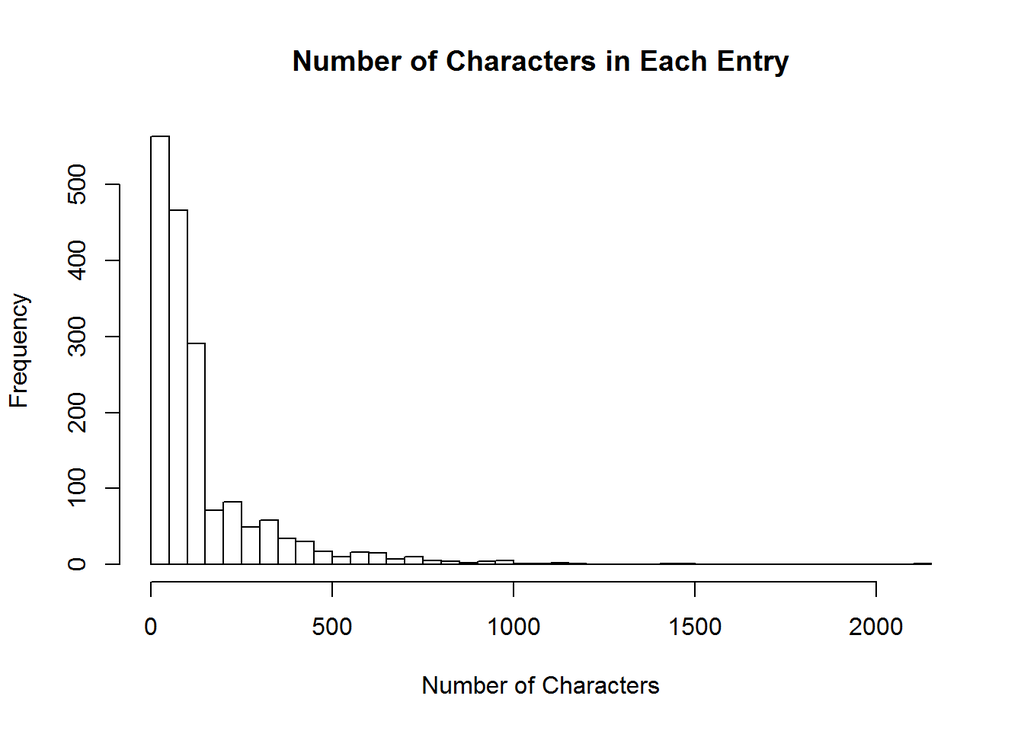

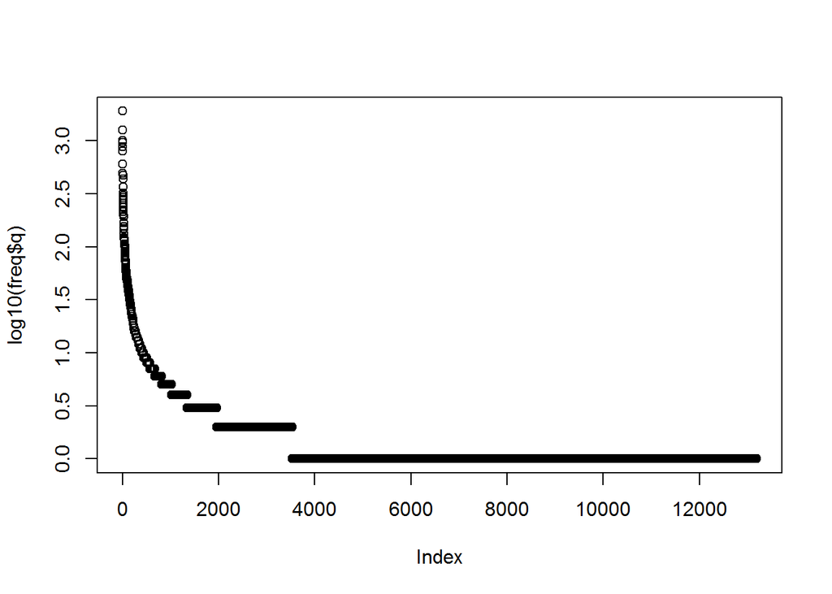

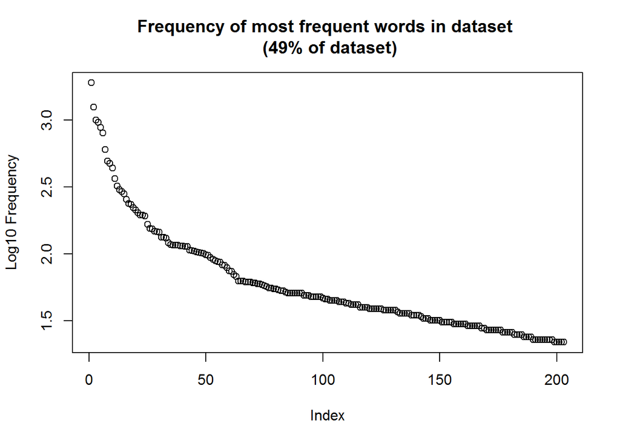

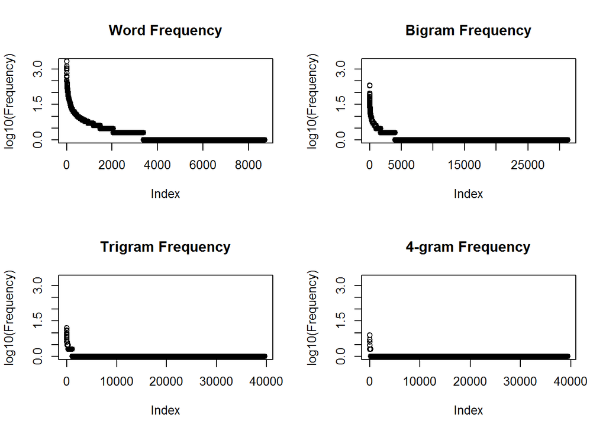

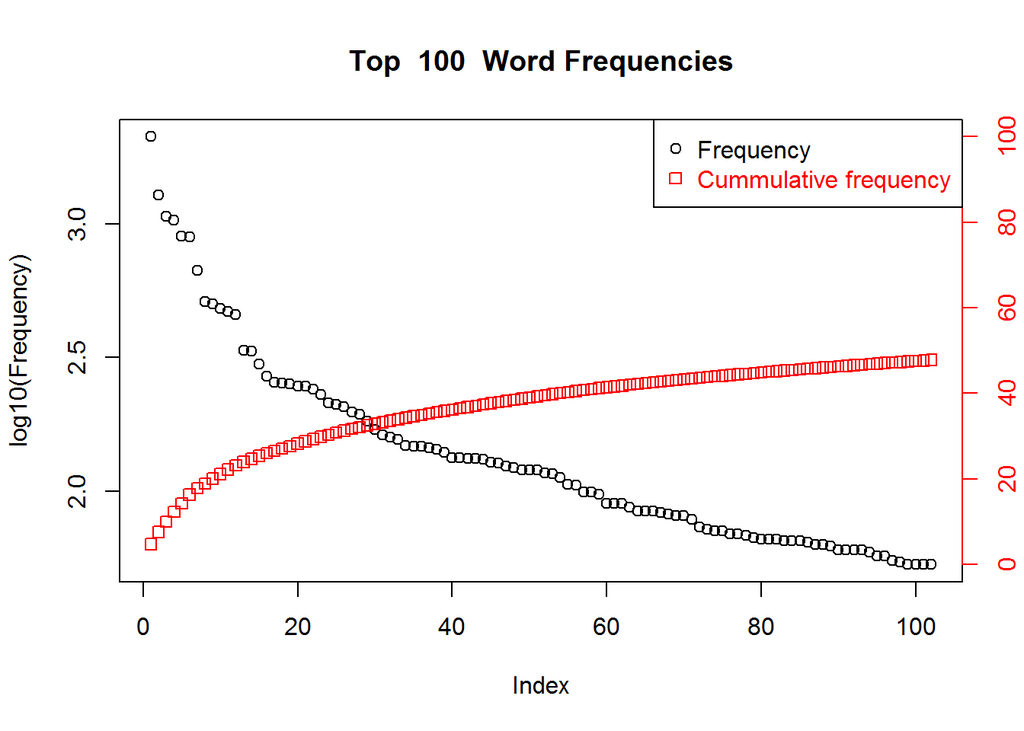

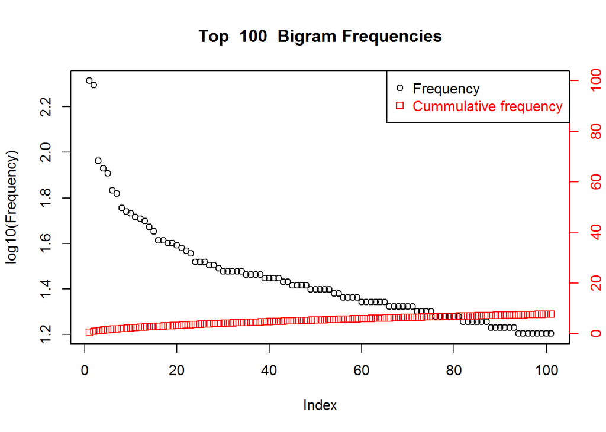

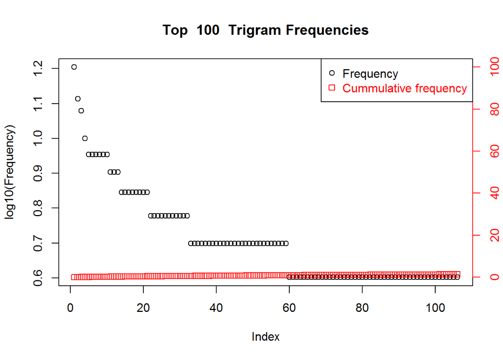

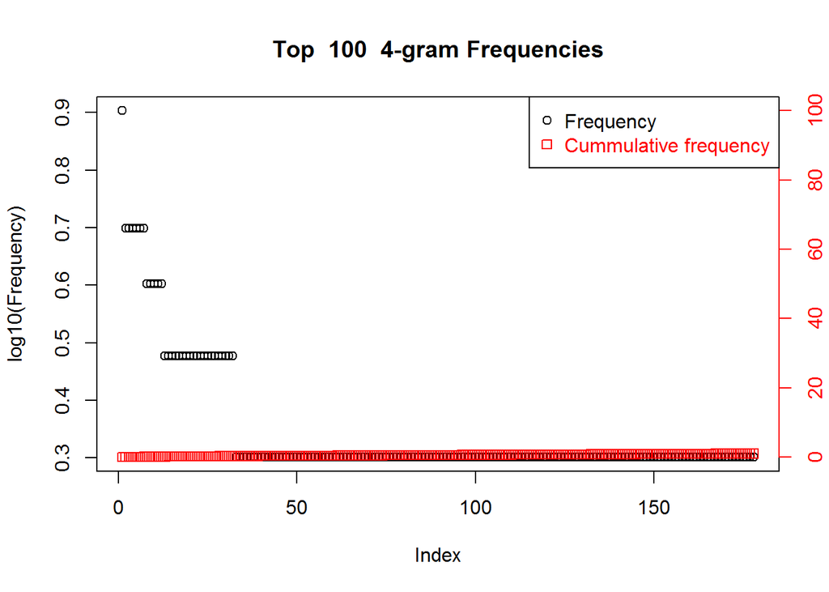

### Objective 3. Report interesting findings

Based on all the graphs produced, there are a few frequent words and then there is a steep drop in frequencies yielding a long tail of low-frequency words. Nonetheless, about half of the dataset is composed of only 200 words! The same can be said with the n-grams. However, the larger the n-gram, the steeper the decline in high frequency. This is expected since a group of words in a specific order will be less frequent than a single word.

Most of the high-frequency words are articles like “the” and prepositions like “of”. Combinations of these are the most common bigrams. Trigrams and 4-grams appear to be more dependant on the dataset (than the English language). The word ‘prom’ appears repeated many times in the dataset.You can see the top 20 words, bigrams, trigrams and 4-grams in the table below.

```
##       Words  Bigram     Trigram          4-gram
##  [1,] "the"  "of_the"   "one_of_the"     "prom_prom_prom_prom"
##  [2,] "to"   "in_the"   "thanks_for_the" "at_the_top_of"
##  [3,] "and"  "to_the"   "to_be_a"        "the_end_of_the"
##  [4,] "a"    "for_the"  "i_have_a"       "when_it_comes_to"
##  [5,] "of"   "to_be"    "a_couple_of"    "la_la_la_la"
##  [6,] "i"    "at_the"   "a_lot_of"       "superior_to_president_obama"
##  [7,] "in"   "on_the"   "i_want_to"      "to_president_obama_in"
##  [8,] "for"  "i_have"   "prom_prom_prom" "at_the_same_time"
##  [9,] "is"   "and_the"  "out_of_the"     "the_top_of_the"
## [10,] "that" "i_am"     "as_well_as"     "if_you_want_to"
## [11,] "it"   "it_is"    "it_is_a"        "who_performs_under_the"
## [12,] "you"  "is_a"     "you_have_to"    "performs_under_the_name"
## [13,] "my"   "is_the"   "i_had_to"       "i_don't_want_to"
## [14,] "on"   "it_was"   "i_am_not"       "i_am_trying_to"
## [15,] "with" "for_a"    "be_able_to"     "thank_you_all_for"
## [16,] "was"  "of_a"     "going_to_be"    "i_know_i_know"
## [17,] "this" "with_the" "in_the_past"    "i_don't_think_you"
## [18,] "have" "in_a"     "it_was_a"       "the_name_of_the"
## [19,] "but"  "have_a"   "the_end_of"     "at_the_end_of"
## [20,] "as"   "going_to" "in_the_world"   "john_smithâ_s_grand"
```

### Objective 4. Receive feedback on plans to create a prediction algorithm

My idea to create the algorithm is to use the quanteda package as a way to clean and search from term frequency matrices. A word will the searched through a sorted list (to improve speed) based on the frequency. The algorithm will first search on a list of most frequent trigrams, if nothing is found, a bigram database will be searched. Finally, if nothing was found, the top pick of the most frequent words will be return based on what figure of speech was the input word. In other words, if the user types a noun, ‘car’ for example, a verb will be returned, such as ‘is’ and not another noun or pronoun, such as ‘I’. I decided not to exclude contractions from the dataset as they are commonly use in English. Similarly, if other language word is frequently used, I didn’t want to exclude it either. However, symbols, numbers and punctuation were excluded and will not be predicted.

END OF DOCUMENT